# Analisis Pola Penyewaan dan Pendapatan Toko DVD

Studi Kasus: Database Sakila

Dani Ramadhan — M0725032

25 Mei 2026

**Nama:** Dani Ramadhan | **NIM:** M0725032 | **Kelas:** D | **Mata Kuliah:** Sistem Informasi Manajemen

# 1 Pendahuluan

## 1.1 Deskripsi Data dan Insight

**Tentang Database Sakila**  
Database *Sakila* adalah contoh database relasional yang dikembangkan oleh MySQL untuk merepresentasikan sistem manajemen toko penyewaan DVD. Database ini terdiri dari **23 tabel** yang mencakup informasi lengkap mengenai film, pelanggan, staf, transaksi sewa, dan pembayaran.

**Pertanyaan riset:** Bagaimana distribusi pendapatan berdasarkan kategori film, dan apakah terdapat hubungan antara volume penyewaan dengan total pendapatan yang dihasilkan setiap kategori?

Tujuan analisis:

1. Mengidentifikasi kategori film paling diminati berdasarkan volume rental
2. Mengevaluasi kategori film dengan pendapatan tertinggi dan terendah
3. Mengukur variabilitas pendapatan antar kategori menggunakan statistik deskriptif
4. Menganalisis hubungan (korelasi) antara jumlah rental dan total pendapatan

Tabel yang digunakan: `category`, `film_category`, `film`, `inventory`, `rental`, `payment`.

## 1.2 Persamaan Matematis

**Rata-rata pendapatan per kategori:**
$$\bar{X}_{k} = \frac{\sum_{i=1}^{n_k}
P_i}{n_k}$$

di mana $P_i$ adalah nilai pembayaran ke-$i$ pada kategori $k$, dan $n_k$ adalah total transaksi pada kategori tersebut.

**Simpangan baku:**
$$\sigma
= \sqrt{\frac{\sum_{i=1}^{n}(X_i - \bar{X})^2}{n-1}}$$

**Koefisien Variasi (CV):**
$$CV = \frac{\sigma}{\bar{X}} \times
100\%$$

**Korelasi Pearson:**
$$r =
\frac{\sum_{i=1}^{n}(x_i - \bar{x})(y_i -
\bar{y})}{\sqrt{\sum_{i=1}^{n}(x_i - \bar{x})^2 \cdot \sum_{i=1}^{n}(y_i
- \bar{y})^2}}$$

dengan $r \in [-1, 1]$, nilai $|r|$ mendekati 1 menunjukkan korelasi yang kuat.

# 2 Analisis Data

## 2.1 Load Library dan Koneksi Database

```r
library(DBI)
library(RMySQL)
library(tidyverse)
library(ggplot2)
library(scales)
library(kableExtra)
library(ggrepel)
```

```r
con <- dbConnect(
  MySQL(),
  dbname   = "sakila",
  host     = "127.0.0.1",
  port     = 3306,
  user     = "root",
  password = "isi_password_anda"
)
```

**Catatan keamanan:** Password database tidak ditampilkan langsung dalam kode untuk menjaga keamanan kredensial.

## 2.2 Pengambilan Data

```r
df_kategori <- dbGetQuery(con, "
  SELECT
    c.name                 AS kategori,
    COUNT(r.rental_id)     AS total_rental,
    SUM(p.amount)          AS total_pendapatan,
    AVG(p.amount)          AS rata_pendapatan
  FROM category c
  JOIN film_category fc ON c.category_id = fc.category_id
  JOIN film f           ON fc.film_id    = f.film_id
  JOIN inventory i      ON f.film_id     = i.film_id
  JOIN rental r         ON i.inventory_id = r.inventory_id
  JOIN payment p        ON r.rental_id   = p.rental_id
  GROUP BY c.name
  ORDER BY total_pendapatan DESC
")
dbDisconnect(con)
```

## 2.3 Statistik Deskriptif

### 2.3.1 Tabel Ringkasan

```r
df_kategori %>%
  mutate(
    total_pendapatan = dollar(total_pendapatan, accuracy = 0.01),
    rata_pendapatan  = dollar(rata_pendapatan,  accuracy = 0.01),
    total_rental     = comma(total_rental)
  ) %>%
  rename(
    "Kategori"               = kategori,
    "Total Rental"           = total_rental,
    "Total Pendapatan (USD)" = total_pendapatan,
    "Rata-rata / Transaksi"  = rata_pendapatan
  ) %>%
  kable(caption = "Tabel 1. Ringkasan Pendapatan dan Volume Rental per Kategori Film",
        align = c("l","r","r","r")) %>%
  kable_styling(bootstrap_options = c("striped","hover","bordered","condensed"),
                full_width = TRUE, font_size = 13) %>%
  row_spec(0,  bold = TRUE, color = "white", background = "#1565c0") %>%
  row_spec(1,  bold = TRUE, background = "#fff9c4") %>%
  row_spec(16, background = "#fce4ec")
```

Tabel 1. Ringkasan Pendapatan dan Volume Rental per Kategori Film

| Kategori | Total Rental | Total Pendapatan (USD) | Rata-rata / Transaksi |
| --- | --- | --- | --- |
| Sports | 1,179 | $5,314.21 | $4.51 |
| Sci-Fi | 1,101 | $4,756.98 | $4.32 |
| Animation | 1,166 | $4,656.30 | $3.99 |
| Drama | 1,060 | $4,587.39 | $4.33 |
| Comedy | 941 | $4,383.58 | $4.66 |
| Action | 1,112 | $4,375.85 | $3.93 |
| New | 940 | $4,351.62 | $4.63 |
| Games | 969 | $4,281.33 | $4.42 |
| Foreign | 1,033 | $4,270.67 | $4.13 |
| Family | 1,096 | $4,226.07 | $3.86 |
| Documentary | 1,050 | $4,217.52 | $4.02 |
| Horror | 846 | $3,722.54 | $4.40 |
| Children | 945 | $3,655.55 | $3.87 |
| Classics | 939 | $3,639.59 | $3.88 |
| Travel | 837 | $3,549.64 | $4.24 |
| Music | 830 | $3,417.72 | $4.12 |

### 2.3.2 Ukuran Pemusatan & Penyebaran

```r
cv <- round(sd(df_kategori$total_pendapatan) /
            mean(df_kategori$total_pendapatan) * 100, 2)

data.frame(
  Ukuran = c("Minimum","Kuartil 1 (Q1)","Median (Q2)",
             "Mean (Rata-rata)","Kuartil 3 (Q3)","Maksimum",
             "Simpangan Baku (SD)",
             paste0("Koefisien Variasi = ", cv, "%")),
  Nilai = c(
    dollar(min(df_kategori$total_pendapatan), accuracy=0.01),
    dollar(quantile(df_kategori$total_pendapatan, 0.25), accuracy=0.01),
    dollar(median(df_kategori$total_pendapatan), accuracy=0.01),
    dollar(mean(df_kategori$total_pendapatan), accuracy=0.01),
    dollar(quantile(df_kategori$total_pendapatan, 0.75), accuracy=0.01),
    dollar(max(df_kategori$total_pendapatan), accuracy=0.01),
    dollar(sd(df_kategori$total_pendapatan), accuracy=0.01),
    paste0(cv, "%")
  )
) %>%
  kable(caption = "Tabel 2. Statistik Deskriptif Total Pendapatan per Kategori",
        col.names = c("Ukuran Statistik","Nilai"), align = c("l","r")) %>%
  kable_styling(bootstrap_options = c("striped","hover","bordered"),
                full_width = FALSE, font_size = 13) %>%
  row_spec(0, bold = TRUE, color = "white", background = "#283593") %>%
  row_spec(4, bold = TRUE, background = "#e8f4fd") %>%
  row_spec(8, bold = TRUE, background = "#e8f5e9")
```

Tabel 2. Statistik Deskriptif Total Pendapatan per Kategori

| Ukuran Statistik | Nilai |
| --- | --- |
| Minimum | $3,417.72 |
| Kuartil 1 (Q1) | $3,705.79 |
| Median (Q2) | $4,276.00 |
| Mean (Rata-rata) | $4,212.91 |
| Kuartil 3 (Q3) | $4,434.53 |
| Maksimum | $5,314.21 |
| Simpangan Baku (SD) | $508.65 |
| Koefisien Variasi = 12.07% | 12.07% |

## 2.4 Visualisasi Data

### 2.4.1 Visualisasi 1: Pendapatan per Kategori Film

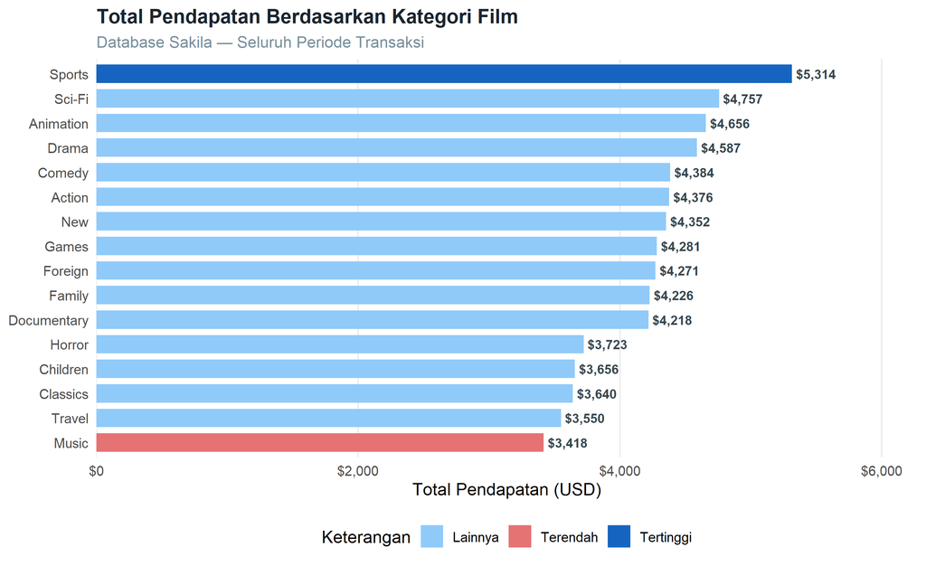

Gambar 1. Total pendapatan berdasarkan kategori film. Biru tua = tertinggi, merah = terendah.

```r
df_kategori %>%
  mutate(highlight = case_when(
    total_pendapatan == max(total_pendapatan) ~ "Tertinggi",
    total_pendapatan == min(total_pendapatan) ~ "Terendah",
    TRUE ~ "Lainnya"
  )) %>%
  ggplot(aes(x = reorder(kategori, total_pendapatan),
             y = total_pendapatan, fill = highlight)) +
  geom_col(width = 0.75) +
  geom_text(aes(label = dollar(total_pendapatan, accuracy = 1)),
            hjust = -0.1, size = 3.2, color = "#37474f", fontface = "bold") +
  coord_flip() +
  scale_fill_manual(
    values = c("Tertinggi"="#1565c0","Terendah"="#e57373","Lainnya"="#90caf9"),
    name = "Keterangan") +
  scale_y_continuous(labels = dollar_format(),
                     expand = expansion(mult = c(0, 0.18))) +
  labs(title    = "Total Pendapatan Berdasarkan Kategori Film",
       subtitle = "Database Sakila — Seluruh Periode Transaksi",
       x = NULL, y = "Total Pendapatan (USD)") +
  theme_minimal(base_size = 12) +
  theme(plot.title         = element_text(face="bold", color="#1a252f", size=14),
        plot.subtitle      = element_text(color="#78909c", size=11),
        legend.position    = "bottom",
        panel.grid.major.y = element_blank(),
        panel.grid.minor   = element_blank())
```

### 2.4.2 Visualisasi 2: Korelasi Rental dan Pendapatan

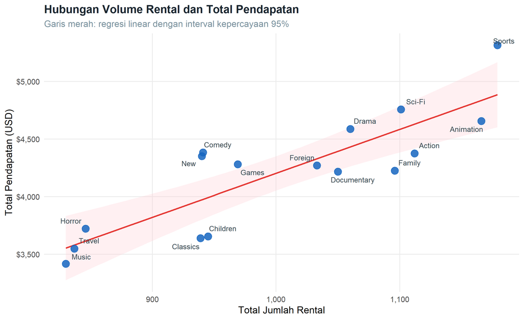

Gambar 2. Scatter plot hubungan volume rental dan total pendapatan per kategori.

```r
ggplot(df_kategori, aes(x = total_rental, y = total_pendapatan)) +
  geom_smooth(method = "lm", se = TRUE, color = "#e53935",
              fill = "#ffcdd2", alpha = 0.3, linewidth = 1) +
  geom_point(color = "#1565c0", size = 4, alpha = 0.85) +
  geom_text_repel(aes(label = kategori), size = 3.2, color = "#37474f",
                  box.padding = 0.4, max.overlaps = 20) +
  scale_x_continuous(labels = comma_format()) +
  scale_y_continuous(labels = dollar_format()) +
  labs(title    = "Hubungan Volume Rental dan Total Pendapatan",
       subtitle = "Garis merah: regresi linear dengan interval kepercayaan 95%",
       x = "Total Jumlah Rental", y = "Total Pendapatan (USD)") +
  theme_minimal(base_size = 12) +
  theme(plot.title    = element_text(face="bold", color="#1a252f", size=14),
        plot.subtitle = element_text(color="#78909c", size=11),
        panel.grid.minor = element_blank())
```

### 2.4.3 Uji Korelasi Pearson

```r
cor_test  <- cor.test(df_kategori$total_rental,
                      df_kategori$total_pendapatan, method = "pearson")
model     <- lm(total_pendapatan ~ total_rental, data = df_kategori)
r_squared <- summary(model)$r.squared

data.frame(
  Statistik = c("Koefisien korelasi (r)","R-squared (R²)",
                "P-value","Intersep (a)","Koefisien regresi (b)","Kesimpulan"),
  Nilai = c(
    round(cor_test$estimate, 4),
    round(r_squared, 4),
    round(cor_test$p.value, 4),
    round(coef(model)[1], 3),
    round(coef(model)[2], 4),
    ifelse(cor_test$p.value < 0.05,
           "Signifikan (p < 0.05)", "Tidak signifikan (p >= 0.05)")
  )
) %>%
  kable(caption = "Tabel 3. Hasil Uji Korelasi Pearson",
        col.names = c("Statistik","Nilai"), align = c("l","r")) %>%
  kable_styling(bootstrap_options = c("striped","hover","bordered"),
                full_width = FALSE, font_size = 13) %>%
  row_spec(0, bold = TRUE, color = "white", background = "#283593") %>%
  row_spec(6, bold = TRUE, background = "#e8f5e9")
```

Tabel 3. Hasil Uji Korelasi Pearson

| Statistik | Nilai |
| --- | --- |
| Koefisien korelasi (r) | 0.8487 |
| R-squared (R²) | 0.7203 |
| P-value | 0 |
| Intersep (a) | 392.803 |
| Koefisien regresi (b) | 3.8096 |
| Kesimpulan | Signifikan (p < 0.05) |

Persamaan regresi linear yang diperoleh:

$$\widehat{Y} = 392.8 + 3.8096 \cdot
X$$

di mana $\widehat{Y}$ adalah prediksi total pendapatan (USD) dan $X$ adalah jumlah rental.